# Practical Machine Learning Course Project

## Synopsis

Personal fitness tracking devices collect a large amount of data about the activity of the wearer. Data was measured from accelerometers on the belt, forearm, arm, and dumbbell of 6 participants. They were asked to perform barbell lifts correctly and incorrectly in 5 different ways.

## Dataset

A description of the dataset can be found in the appendix.

## Cleaning Data

Please see appendix for R environment setup. The training and test datasets are read and assigned to `trainingRaw` and `testingRaw` data frames respectively. An initial look at the dimensions of `trainingRaw` and `testingRaw`:

```r
dim(trainingRaw)
```

```
## [1] 19622   160
```

```r
dim(testingRaw)
```

```
## [1]  20 160
```

`trainingRaw` has 19622 observations of 160 variables, and `testingRaw` has 20 observations of 160 variables. The `classe` variable in `trainingRaw` is the outcome for prediction. This variable is replaced by `problem_id` in `testingRaw`. See appendix for full list of variable names.

Then, the following cleaning operations were performed, with code in the appendix:

1. The first seven variables are unrelated to the measurements taken by the accelerometers, and are removed. The resulting dataframes are assigned to `training` and `testing` data frames.
2. Variables with near zero variability were removed.
3. Variables with all NA values were removed.

```r
dim(training)
```

```
## [1] 19622    53
```

```r
dim(testing)
```

```
## [1] 20 53
```

Both sets have had their amount of variables reduced to 53.

## Correlation Matrix

A correlation matrix between the 52 potential indicator variables is plotted.

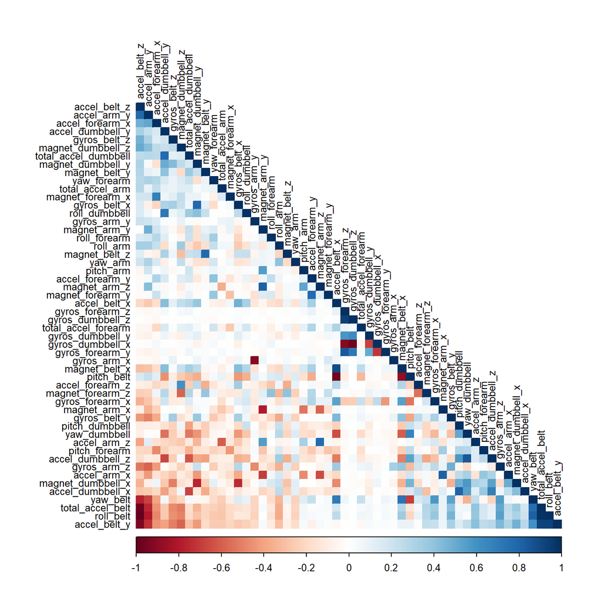

```r
corrMatrix <- cor(training[, -53])
corrplot(corrMatrix, order = "FPC", method = "color", type = "lower",
         tl.cex = 0.8, tl.col = rgb(0, 0, 0))
```

There does not appear to be many highly correlated variables, so PCA will not be performed.

## Data Slicing

`training` will be split 80% into a sub-training set `subtraining`, and the remaining 20% as a validation set `validation` for the predictive models.

```r
set.seed(33233)
inTrain <- createDataPartition(training$classe, p=0.80, list=F)
subtraining <- training[inTrain,]
validation <- training[-inTrain,]
dim(subtraining)
```

```
## [1] 15699    53
```

```r
dim(validation)
```

```
## [1] 3923   53
```

The dimensions of each are as above.

## Prediction Modelling

### Random Forest

```r
cvcontrol <- trainControl(method="cv", 5)
rfModel <- train(classe ~ ., data = subtraining, method="rf", trControl=cvcontrol)
rfModel
```

```
## Random Forest
##
## 15699 samples
##    52 predictor
##     5 classes: 'A', 'B', 'C', 'D', 'E'
##
## No pre-processing
## Resampling: Cross-Validated (5 fold)
## Summary of sample sizes: 12560, 12558, 12558, 12560, 12560
## Resampling results across tuning parameters:
##
##   mtry  Accuracy   Kappa
##    2    0.9912737  0.9889604
##   27    0.9914647  0.9892025
##   52    0.9852861  0.9813863
##
## Accuracy was used to select the optimal model using the largest value.
## The final value used for the model was mtry = 27.
```

Then calculate accuracy of prediction on the validation set. This will be compared to the boosted model.

```r
rfPredict <- predict(rfModel, validation)
confusionMatrix(factor(validation$classe), rfPredict)
```

```
## Confusion Matrix and Statistics
##
##           Reference
## Prediction    A    B    C    D    E
##          A 1116    0    0    0    0
##          B    4  755    0    0    0
##          C    0    5  677    2    0
##          D    0    0    8  634    1
##          E    0    0    2    3  716
##
## Overall Statistics
##
##                Accuracy : 0.9936
##                  95% CI : (0.9906, 0.9959)
##     No Information Rate : 0.2855
##     P-Value [Acc > NIR] : < 2.2e-16
##
##                   Kappa : 0.9919
##
##  Mcnemar's Test P-Value : NA
##
## Statistics by Class:
##
##                      Class: A Class: B Class: C Class: D Class: E
## Sensitivity            0.9964   0.9934   0.9854   0.9922   0.9986
## Specificity            1.0000   0.9987   0.9978   0.9973   0.9984
## Pos Pred Value         1.0000   0.9947   0.9898   0.9860   0.9931
## Neg Pred Value         0.9986   0.9984   0.9969   0.9985   0.9997
## Prevalence             0.2855   0.1937   0.1751   0.1629   0.1828
## Detection Rate         0.2845   0.1925   0.1726   0.1616   0.1825
## Detection Prevalence   0.2845   0.1935   0.1744   0.1639   0.1838
## Balanced Accuracy      0.9982   0.9961   0.9916   0.9947   0.9985
```

The random forest model has a 99.36% accuracy rate. Thus we can expect our out of sample error rate to be close to, but higher than 0.64%.

### Boosting with Trees

```r
gbmModel <- train(classe~., subtraining, method = 'gbm', trControl=cvcontrol, verbose = F)
gbmModel
```

```
## Stochastic Gradient Boosting
##
## 15699 samples
##    52 predictor
##     5 classes: 'A', 'B', 'C', 'D', 'E'
##
## No pre-processing
## Resampling: Cross-Validated (5 fold)
## Summary of sample sizes: 12559, 12560, 12559, 12559, 12559
## Resampling results across tuning parameters:
##
##   interaction.depth  n.trees  Accuracy   Kappa
##   1                   50      0.7490293  0.6818080
##   1                  100      0.8238744  0.7770402
##   1                  150      0.8550864  0.8166524
##   2                   50      0.8570609  0.8188414
##   2                  100      0.9068091  0.8820506
##   2                  150      0.9305050  0.9120615
##   3                   50      0.9011405  0.8748475
##   3                  100      0.9419709  0.9265781
##   3                  150      0.9620993  0.9520522
##
## Tuning parameter 'shrinkage' was held constant at a value of 0.1
##
## Tuning parameter 'n.minobsinnode' was held constant at a value of 10
## Accuracy was used to select the optimal model using the largest value.
## The final values used for the model were n.trees = 150, interaction.depth =
##  3, shrinkage = 0.1 and n.minobsinnode = 10.
```

Then calculate accuracy of prediction on the validation set.

```r
gbmPredict <- predict(gbmModel, validation)
confusionMatrix(factor(validation$classe), gbmPredict)
```

```
## Confusion Matrix and Statistics
##
##           Reference
## Prediction    A    B    C    D    E
##          A 1097   12    4    3    0
##          B   29  714   15    1    0
##          C    1   25  650    7    1
##          D    1    2   30  605    5
##          E    3   10    6    9  693
##
## Overall Statistics
##
##                Accuracy : 0.9582
##                  95% CI : (0.9515, 0.9642)
##     No Information Rate : 0.2883
##     P-Value [Acc > NIR] : < 2.2e-16
##
##                   Kappa : 0.9471
##
##  Mcnemar's Test P-Value : 2.47e-06
##
## Statistics by Class:
##
##                      Class: A Class: B Class: C Class: D Class: E
## Sensitivity            0.9699   0.9358   0.9220   0.9680   0.9914
## Specificity            0.9932   0.9858   0.9894   0.9885   0.9913
## Pos Pred Value         0.9830   0.9407   0.9503   0.9409   0.9612
## Neg Pred Value         0.9879   0.9845   0.9830   0.9939   0.9981
## Prevalence             0.2883   0.1945   0.1797   0.1593   0.1782
## Detection Rate         0.2796   0.1820   0.1657   0.1542   0.1767
## Detection Prevalence   0.2845   0.1935   0.1744   0.1639   0.1838
## Balanced Accuracy      0.9816   0.9608   0.9557   0.9782   0.9914
```

The boosted model has a 95.82% accuracy rate. Thus we can expect our out of sample error rate to be close to, but higher than 4.18%. Comparing rates, the random forest model will be selected to use with the test set.

### Prediction

Fit `testing` to the random forest model, removing the `problem_id` variable, which is not needed.

```r
prediction <- predict(rfModel, testing[,-53])
prediction
```

```
##  [1] B A B A A E D B A A B C B A E E A B B B
## Levels: A B C D E
```

## Appendix

### Dataset Description

Six young health participants were asked to perform one set of 10 repetitions of the Unilateral Dumbbell Biceps Curl in five different fashions: exactly according to the specification (Class A), throwing the elbows to the front (Class B), lifting the dumbbell only halfway (Class C), lowering the dumbbell only halfway (Class D) and throwing the hips to the front (Class E).

Class A corresponds to the specified execution of the exercise, while the other 4 classes correspond to common mistakes. Participants were supervised by an experienced weight lifter to make sure the execution complied to the manner they were supposed to simulate. The exercises were performed by six male participants aged between 20-28 years, with little weight lifting experience. We made sure that all participants could easily simulate the mistakes in a safe and controlled manner by using a relatively light dumbbell (1.25kg).

### R Environment

```r
library(caret); library(corrplot); library(dplyr)
```

### Variable Names

```r
names(trainingRaw)
```

```
##   [1] "X"                        "user_name"
##   [3] "raw_timestamp_part_1"     "raw_timestamp_part_2"
##   [5] "cvtd_timestamp"           "new_window"
##   [7] "num_window"               "roll_belt"
##   [9] "pitch_belt"               "yaw_belt"
##  [11] "total_accel_belt"         "kurtosis_roll_belt"
##  [13] "kurtosis_picth_belt"      "kurtosis_yaw_belt"
##  [15] "skewness_roll_belt"       "skewness_roll_belt.1"
##  [17] "skewness_yaw_belt"        "max_roll_belt"
##  [19] "max_picth_belt"           "max_yaw_belt"
##  [21] "min_roll_belt"            "min_pitch_belt"
##  [23] "min_yaw_belt"             "amplitude_roll_belt"
##  [25] "amplitude_pitch_belt"     "amplitude_yaw_belt"
##  [27] "var_total_accel_belt"     "avg_roll_belt"
##  [29] "stddev_roll_belt"         "var_roll_belt"
```

[output cut: 65 more lines]

Return names in testingRaw that are not present in trainingRaw

```r
names(testingRaw[names(testingRaw) != names(trainingRaw)])
```

```
## [1] "problem_id"
```

### Cleaning

```r
training <- trainingRaw[,-(1:7)]
testing <- testingRaw[,-(1:7)]

nsv <- nearZeroVar(training)
training <- training[, -nsv]
testing  <- testing[, -nsv]

training <- select(training, where(function(x) sum(is.na(x)) == 0))
testing <- select(testing, where(function(x) sum(is.na(x)) == 0))
```